# RL Chapter 3 Reading Response

18 June 2020

## Questions

**1.** To what extent can MDP's model multi-player games? Take the card game Poker for example. The state transitions depend not only on the actions of the agent, but on the actions of every other player as well. In fact, being able to predict the actions of other players is the key to successful play. An agent that performs well against one set of opponents may be completely ineffective against another set.

My first guess is it may be possible to encode belief about the future behavior of opponents within an agent's state, but I haven't thought it through. As the class progresses I would like to try creating an agent to learn to play Poker.

**2.** Are abstractions learned by an agent, or are they built-in by the programmer?

**3.** The book is emphatic that subgoals should not be rewarded:

> In particular, the reward signal is not the place to impart to the agent prior knowledge about how to achieve what we want it to do. For example, a chess-playing agent should be rewarded only for actually winning, not for achieving subgoals such as taking its opponent’s pieces or gaining control of the center of the board.

It seems to me that this would make it extremely difficult for an agent to learn how to play (the lectures touched on this point as well). Should we really take the book at face value on this, or is there a bit more nuance? I hope we cover reward functions in more detail as we start learning practical techniques.

## MDP Examples:

Besides Poker, I thought of two other scenarios that I wish to explore in this class.

**Calming a crying baby** modeled as a POMDP. Say we have a baby that cries when it is either hungry or soiled. When the baby is hungry, we need to feed it, and when it is soiled, we need to change it's diaper.

The true state-space of the baby is $\{Happy, Soiled, Hungry\}$, but the only signal we are able to observe is $\{Smiling, Crying\}$. The baby is always $Smiling$ when it is $Happy$, and it is $Crying$ when it is $Soiled$ or $Hungry$. The available actions are $\{Play, Feed, Change\}$.

Ideally, we want the agent to $Play$ when the baby is $Smiling$, and either $Feed$ or $Change$ when the baby is $Crying$. If the baby still is still $Crying$ after trying one of those actions, the agent then tries the other one. Furthermore, we hope that the agent can learn to pick the right option between $Feed$ and $Change$ on the first try based on the dynamics of the baby.

I know we will not cover POMDPs extensively in this class, but this example is simple enough that it might be fruitful to have a go at it anyway.

**Building a data cache.** We want a data cache with a high probability of having the next requested resource already in it's cached set. In this example, the reward function is easy: $+1$ for a cache hit, and $-1$ for a cache miss.

The much more interesting question is how to model the state as an MDP. The first idea I want to try is to keep track of the last $n$ requests. I hope this strategy allows the agent to learn when to pre-fetch resources that are commonly requested in a sequence. There may be other dimensions that would be useful to keep track of in the state, like time of day.

I'd like to try building such a cache later in this course and evaluate it against standard strategies like LRU on real datasets.

## Experiments

1. To make sure that I understood the Bellman Equations, I reproduced the Gridworld example from the book. I was able to model the state value function as a system of linear equations and solve it to get the same result as Figure 3.2.
1. The critical insight that there is a single $v_*$ where *every* state value is optimal suggests a simple gradient algorithm to improve a policy. At each timestep, for every state we find the gradient of the state value with respect to the action probabilities and adjust the action probabilities acordingly. I implemented this approach and it found an essentially optimal strategy very quickly.

### Reproducing the state value function for Gridworld

```python
import numpy as np
import matplotlib.pyplot as plt
```

```python
NORTH = 0
SOUTH = 1
EAST = 2
WEST = 3

ACTIONS = [NORTH, SOUTH, EAST, WEST]

def next_state_and_reward(i, j, action):
    if action == NORTH:
        if i == 0 and j == 1:
            r = 10
            next_i = 4
            next_j = j
        elif i == 0 and j == 3:
            r = 5
            next_i = 2
            next_j = j
        elif i == 0:
            r = -1
            next_i = i
            next_j = j
        else:
            r = 0
            next_i = i-1
            next_j = j

    elif action == SOUTH:
        if i == 0 and j == 1:
            r = 10
            next_i = 4
            next_j = j
        elif i == 0 and j == 3:
            r = 5
            next_i = 2
            next_j = j
        elif i == 4:
            r = -1
            next_i = i
            next_j = j
        else:
            r = 0
            next_i = i+1
            next_j = j

    elif action == EAST:
        if i == 0 and j == 1:
            r = 10
            next_i = 4
            next_j = j
        elif i == 0 and j == 3:
            r = 5
            next_i = 2
            next_j = j
        elif j == 4:
            r = -1
            next_i = i
            next_j = j
        else:
            r = 0
            next_i = i
            next_j = j+1

    elif action == WEST:
        if i == 0 and j == 1:
            r = 10
            next_i = 4
            next_j = j
        elif i == 0 and j == 3:
            r = 5
            next_i = 2
            next_j = j
        elif j == 0:
            r = -1
            next_i = i
            next_j = j
        else:
            r = 0
            next_i = i
            next_j = j-1

    else:
        raise Exception("Unhandled action: ", action)

    return next_i, next_j, r


def calculate_value_system(actions):
    next_step = np.zeros([25, 25])
    rewards = np.zeros(25)

    for i in range(5):
        for j in range(5):
            for a in ACTIONS:
                next_i, next_j, r = next_state_and_reward(i, j, a)
                next_step[5*i+j, 5*next_i+next_j] += actions[i,j,a]
                rewards[5*i+j] -= actions[i,j,a] * r

    return next_step, rewards
```

```python
actions = np.ones([5, 5, 4]) * 1/4
next_step, rewards = calculate_value_system(actions)
```

`next_step` is a $25 \times 25$ matrix that stores the probabilities of moving from each square to any other for a particular policy. The output below shows that for the upper-left square, there is a $0.5$ chance of ending up in the same square, a $0.25$ chance of moving one square to the right, a $0.25$ chance of moving one square down, and a $0$ chance of moving anywhere else.

```python
next_step[:1]
```

```
array([[0.5 , 0.25, 0.  , 0.  , 0.  , 0.25, 0.  , 0.  , 0.  , 0.  , 0.  ,
        0.  , 0.  , 0.  , 0.  , 0.  , 0.  , 0.  , 0.  , 0.  , 0.  , 0.  ,
        0.  , 0.  , 0.  ]])
```

`rewards` stores the expected reward for each square using a given policy.

```python
rewards.reshape(5,5)
```

```
array([[  0.5 , -10.  ,   0.25,  -5.  ,   0.5 ],
       [  0.25,   0.  ,   0.  ,   0.  ,   0.25],
       [  0.25,   0.  ,   0.  ,   0.  ,   0.25],
       [  0.25,   0.  ,   0.  ,   0.  ,   0.25],
       [  0.5 ,   0.25,   0.25,   0.25,   0.5 ]])
```

Below, `M` is the result of some some simple algebra (not shown) and it is the matrix that encodes the linear system we need to solve.

```python
gamma = 0.9
M = (next_step * gamma) - np.eye(25,25)
M[:2]
```

```
array([[-0.55 ,  0.225,  0.   ,  0.   ,  0.   ,  0.225,  0.   ,  0.   ,
         0.   ,  0.   ,  0.   ,  0.   ,  0.   ,  0.   ,  0.   ,  0.   ,
         0.   ,  0.   ,  0.   ,  0.   ,  0.   ,  0.   ,  0.   ,  0.   ,
         0.   ],
       [ 0.   , -1.   ,  0.   ,  0.   ,  0.   ,  0.   ,  0.   ,  0.   ,
         0.   ,  0.   ,  0.   ,  0.   ,  0.   ,  0.   ,  0.   ,  0.   ,
         0.   ,  0.   ,  0.   ,  0.   ,  0.   ,  0.9  ,  0.   ,  0.   ,
         0.   ]])
```

We are ready to solve the linear system. Our results match Figure 3.2.

```python
state_values = np.linalg.solve(M, rewards)
state_values_grid = state_values.reshape(5,5)
state_values_grid.round(1)
```

```
array([[ 3.3,  8.8,  4.4,  5.3,  1.5],
       [ 1.5,  3. ,  2.3,  1.9,  0.5],
       [ 0.1,  0.7,  0.7,  0.4, -0.4],
       [-1. , -0.4, -0.4, -0.6, -1.2],
       [-1.9, -1.3, -1.2, -1.4, -2. ]])
```

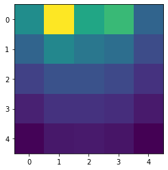

```python
plt.imshow(state_values_grid.round(1))
```

### Experiment: Policy Gradient

Idea: For each state, make it a bit more likely to go in the direction of best next state. Recompute and repeat.

```python
# Save for comparison later
original_state_values_grid = state_values_grid
```

```python
from math import floor

def softmax(vals):
    total = np.sum(np.exp(vals))
    return np.exp(vals) / total


def update_actions(preferences):
    actions = np.empty([5, 5, 4])
    for i in range(5):
        for j in range(5):
            actions[i,j] = softmax(preferences[i,j])
    return actions


preferences = np.ones([5, 5, 4])
actions = update_actions(preferences)
lr = 0.1
gamma = 0.9

for i in range(200):
    next_step, rewards = calculate_value_system(actions)
    M = (next_step * gamma) - np.eye(25,25)
    state_values = np.linalg.solve(M, rewards)
    state_values_grid = state_values.reshape(5,5)

    # Update actions
    for idx, v in enumerate(state_values):
        i = floor(idx / 5)
        j = idx % 5

        grad = np.zeros(4)
        for a in ACTIONS:
            next_i, next_j, _ = next_state_and_reward(i, j, a)
            grad[a] = gamma * state_values_grid[next_i, next_j]

        preferences[i,j] += lr * grad
        actions = update_actions(preferences)
```

The state value grid for our new policy is greater than the state value grid for the original policy at every square.

```python
state_values_grid > original_state_values_grid
```

```
array([[ True,  True,  True,  True,  True],
       [ True,  True,  True,  True,  True],
       [ True,  True,  True,  True,  True],
       [ True,  True,  True,  True,  True],
       [ True,  True,  True,  True,  True]])
```

Our policy is encoded in the `actions` tensor. The output below shows that our new policy will move to the right when in the upper-left square essentially every time.

```python
actions[0,0]
```

```
array([4.48893098e-20, 4.40434771e-37, 1.00000000e+00, 4.48893098e-20])
```

We can easily visualize our policy and see that it matches the optimal policy from Figure 3.5. The size of the arrows show the relative probabilities of making a move. In some squares, our policy has slight preferences for moving one direction vs another, but these preferences do not affect the expected total reward. As we've learned, there are many optimal policies that share the same optimal value function.

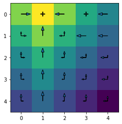

```python
plt.imshow(state_values_grid.round(1))

xs = np.arange(5).repeat(5)
ys = np.tile(np.arange(5), 5)

for i in range(5):
    for j in range(5):
        #North
        arrow_len = actions[i,j,NORTH] * 0.25
        plt.arrow(j,i,0,-arrow_len,head_width=0.5*arrow_len)
        # SOUTH
        arrow_len = actions[i,j,SOUTH] * 0.25
        plt.arrow(j,i,0,arrow_len,head_width=0.5*arrow_len)
        # EAST
        arrow_len = actions[i,j,EAST] * 0.25
        plt.arrow(j,i,arrow_len,0,head_width=0.5*arrow_len)
        # WEST
        arrow_len = actions[i,j,WEST] * 0.25
        plt.arrow(j,i,-arrow_len,0,head_width=0.5*arrow_len)
```

#### Reflection

On my first attempt, increasing iterations doesn't seem to help because I was applying softmax directly to the action probabilities. That's not the way to do it! I took another look at the Gradient methods from chapter 2 and figured out the key is to maintain preferences then apply softmax to that to get accuracy. The key insight is softmax isn't scale invariant:

```python
softmax([1,2])
```

```
array([0.26894142, 0.73105858])
```

```python
softmax([10,20])
```

```
array([4.53978687e-05, 9.99954602e-01])
```

This property means our action probabilities will continue to change as our preferences change even when the action probabilities are close to 0 or 1.

This insight answers a question about softmax vs. clamp and normalize that I didn't even realize I had! Clamp and normalize is incorrect; use softmax on preferences instead.

### Miscellaneous: Proof that $G_t$ is finite if $\{R_k\}$ is bounded:

Lastly, here is a short proof that might not be super interesting, but I didn't have the heart to delete it.

Refer to equation (3.8) on page 55.

> If $\gamma$ < 1, the infinite sum in (3.8) has a finite value as long as the reward sequence $\{R_k\}$ is bounded.

Proof. Let $$ G^{opt}_t = R^{max} + \gamma R^{max} + \gamma^2 R^{max} + \cdots $$

Then $G_t \le G^{opt}$. Use the ratio test to show $G^{opt}$ is finite: $$ \lim_{n \rightarrow \infty} \left| \frac{\gamma^{n+1} R^{max}}{\gamma^n R^{max}} \right| = \gamma < 1 $$

$G_t$ is no greater than than a finite series, so it does not diverge to infinity. A similar approach using $R^{min}$ shows $G_t$ does not diverge to negative infinity. Thus $G_t$ must be finite. []